# STAT 240 Discussion 9

316:4 **Nico Salm**, Dheeraj Pasikanti, Jinming Liu

## Problems

The questions in this discussion assignment use the chimpanzee data set. In answering these questions, you may assume the following in models for the data:

1. all trials are independent
2. trials made with a partner have the same chance of being pro-social, even if the identities of the actors or partners differ.

### Problem 1

#### A

Using the chimpanzee data, combine all of the trials made without a partner. Count the number of pro-social and selfish choices made.

```r
chimp_data <- read.csv('../../data/chimpanzee.csv')

no_partner_data <- chimp_data %>%
  filter(partner == "none")

# count the number of pro-social and selfish choices made
choice_counts <- no_partner_data %>%
  summarise(
    pro_social_count = sum(prosocial, na.rm = TRUE),
    selfish_count = sum(selfish, na.rm = TRUE)
  )
```

#### B

Write a model for the number of pro-social choices.

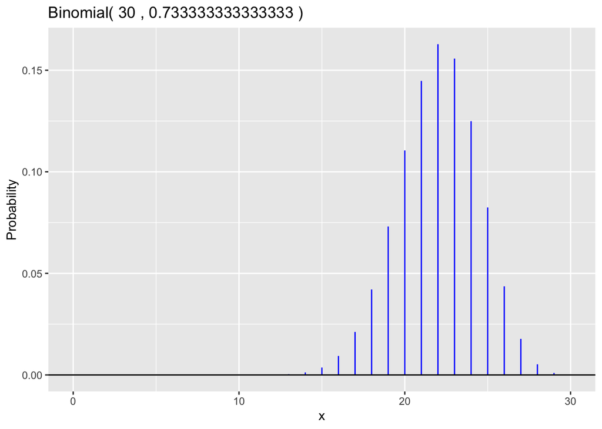

```r
n <- sum(chimp_data$prosocial[1], chimp_data$selfish[1]) # total number of trials
p <- chimp_data$prosocial[1] / n # probability of success (prosocial choice)

# Call the gbinom function with the specified n and p
binom_plot <- gbinom(n, p)
print(binom_plot)
```

#### C

Use the Agresti-Coull method to construct a 95% confidence interval for the probability that a chimpanzee makes the pro-social choice in experimental conditions when there is no partner present.

```r
# the Agresti-Coull interval
x = 83
n = 83 + 97

confidence_int = prop.test(x, n, conf.level = 0.95)
confidence_int$conf.int
```

```
## [1] 0.3871737 0.5367350
## attr(,"conf.level")
## [1] 0.95
```

#### D

We assess with 95% confidence that the true probability of pro-social behavior for chimps with no partners is between 0.387 and 0.537

### Problem 2

Using the same data as in the previous problem, do the following.

#### A

State hypotheses for a two-sided hypothesis test that the probability that a chimpanzee makes the pro-social choice over the long run is equal to 0.5 versus the alternative that this probability is not 0.5.

Null Hypothesis (H₀): p = 0.5

Alternative Hypothesis (H₁): p ≠ 0.5

#### B

Pick a test statistic, state the sampling distribution of this statistic if the null hypothesis is true, and compute a p-value for the test.

```r
t = (x - n * 0.5) / sqrt(n * 0.5 * 0.5)

# the p-value
p_value = 2 * pt(-abs(t), df = n - 1)
```

#### C

Interpret these results in the context of the experiment following the examples from lecture notes.

We see p = 0.29 > 0.05, so we cannot reject the null hypothesis.

### 3

Use functions from the file `ggprob.R` to visualize the calculation of the p-value by graphing an appropriate probability distribution and using differential coloring to indicate what in the plot corresponds to the p-value. Include a title and meaningful axis labels.

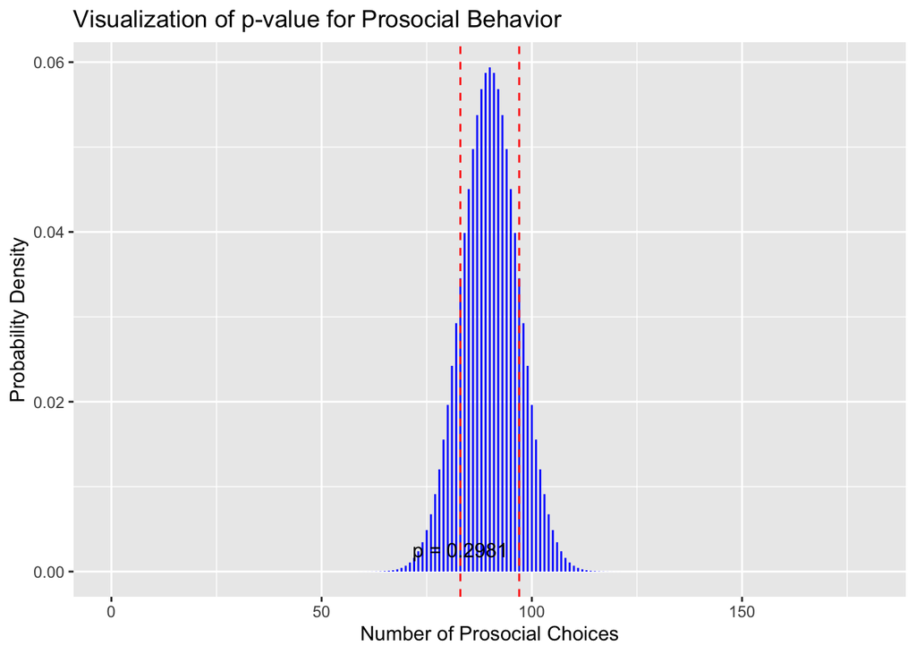

```r
binom_plot <- ggplot(data.frame(x = 0:n), aes(x)) +
  geom_binom_density(n, 0.5) +
  scale_x_continuous(name = "Number of Prosocial Choices") +
  scale_y_continuous(name = "Probability Density") +
  geom_vline(xintercept = x, color = "red", linetype = "dashed") +
  geom_vline(xintercept = n - x, color = "red", linetype = "dashed") +
  ggtitle("Visualization of p-value for Prosocial Behavior") +
  annotate("text", x = x, y = 0, label = paste("p =", round(p_value, 4)), vjust = -1)

print(binom_plot)
```